# homework of StatComp20015

20015

2020-12-15

# 2020-09-22

## Question

Use knitr to produce 3 examples in the book. The 1st example should contain texts and at least one figure. The 2nd example should contains texts and at least one table. The 3rd example should contain at least a couple of LaTeX formulas.

## Answer

#### Example1:

Here are the height and weight data of 15 women, fit the function relationship between height and weight, and draw an image to observe the relationship between height and weight.

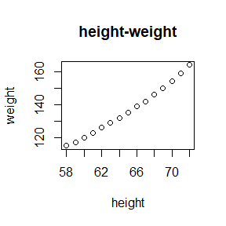

```r
wcoef=lm(women)$coef
plot(women,main='height-weight')
```

#### Example2:

A table formed by the first 10 data of iris.

```r
ir=data.frame(iris[1:10,])
knitr::kable(ir)
```

| Sepal.Length | Sepal.Width | Petal.Length | Petal.Width | Species |
| --- | --- | --- | --- | --- |
| 5.1 | 3.5 | 1.4 | 0.2 | setosa |
| 4.9 | 3.0 | 1.4 | 0.2 | setosa |
| 4.7 | 3.2 | 1.3 | 0.2 | setosa |
| 4.6 | 3.1 | 1.5 | 0.2 | setosa |
| 5.0 | 3.6 | 1.4 | 0.2 | setosa |
| 5.4 | 3.9 | 1.7 | 0.4 | setosa |
| 4.6 | 3.4 | 1.4 | 0.3 | setosa |
| 5.0 | 3.4 | 1.5 | 0.2 | setosa |
| 4.4 | 2.9 | 1.4 | 0.2 | setosa |
| 4.9 | 3.1 | 1.5 | 0.1 | setosa |

#### Example3:

If a random variable $X$ obeys a probability distribution with a position parameter $\mu$ and a scale parameter $\sigma$, and its probability density function is

$$f(x)=\frac{1}{\sqrt{2\pi}\sigma}\exp(-\frac{(x-\mu)^{2}}{2\sigma^2})$$
If $X$ obeys the exponential distribution with parameter $\lambda$, the probability density function of $X$ is

$$f(x)=\lambda e^{-\lambda x},x>0$$

# 2020-09-29

## Question 1

3.3 The Pareto$(a,b)$ distribution has cdf

$$F(x)=1-\left(\frac{b}{x}\right)^{a},\quad x \ge b>0,a>0$$
Derive the probability inverse transformation $F^{-1}(U)$ and use the inverse transform method to simulate a random sample from the Pareto(2,2) distribution. Graph the density histogram of the sample with the Pareto(2,2) density superimposed for comparison.

## Answer 1

$\because a=2,b=2$ $\therefore F^{-1}(y)=\frac{2}{(1-y)^{1/2}},\quad x \ge 2,$ and $f(x)=8x^{-3}$.

n=10000, generate the random observations from $U(0,1)$(called ‘U’), you can get sample from $F^{-1}(y)$ (called ‘da’). Then graph the density histogram of the sample and curve the probability density curve.

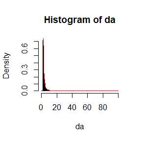

```r
g=function(y) 2/((1-y)^(1/2))
n=1e4
set.seed(1234)
U=runif(n)
da=g(U)
hist(da,breaks=seq(0,100,0.5),freq=F)
curve(8*x^(-3),add=T,col='red')
```

## Question 2

3.9 The rescaled Epanechnikov kernel [85] is a symmetric density function
$$f_{e}(x)=\frac{3}{4}(1-x^{2}),\quad |x|\le1.$$
Devroye and Gy$\ddot{o}$rfi [71,p.236] give the following algorithm for simulation from this distribution. Generate iid $U_{1},U_{2},U_{3} \sim$Uniform(-1,1). If $|U_{3}|\ge|U_{2}|$ and $|U_{3}|\ge|U_{1}|$,deliver $U_{2}$;otherwise deliver $U_{3}$. Write a function to generate random variates from $f_{e}$,and construct the histogram density estimate of a large simulated random sample.

## Answer 2

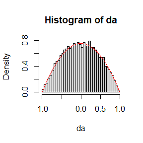

```r
n=1e4
set.seed(2345)
U=matrix(runif(3*n,-1,1),ncol=3)
colnames(U)=c('U1','U2','U3')
da=numeric()
for(i in 1:n){
  if(abs(U[i,3])>=abs(U[i,2]) & abs(U[i,3])>=abs(U[i,1])) da[i]=U[i,2] else
    da[i]=U[i,3]
}
hist(da,breaks = seq(-1,1,0.05),freq=F)
curve(3*(1-x^2)/4,add=T,col='red')
```

## Question 3

3.10 Prove that the algorithm given in Exercise 3.9 generates variates from the density $f_{e}$ (3.10).

## Answer 3

suppose A:$\max\{|U_{1}|,|U_{2}|,|U_{3}|\}=|U_{3}|$,B:$\max\{|U_{1}|,|U_{2}|,|U_{3}|\}=|U_{2}|$,C:$\max\{|U_{1}|,|U_{2}|,|U_{3}|\}=|U_{1}|$.

$\because P(|U_{i}|\le x)=P(-x\le U_{i}\le x)=x,\therefore |U_{i}|\sim U(0,1)$.

$\because U_{i}\sim U(-1,1),\therefore P(U_{i}=x)=\frac{1}{2},x \in (-1,1)$

therefore

$$\begin{aligned}
P(U=x) &= P(U_{2}=x,A)+P(U_{3}=x,B)+P(U_{3}=x,C) \\
&= P(A|U_{2}=x)P(U_{2}=x)+P(B|U_{3}=x)P(U_{3}=x)+P(C|U_{3}=x)P(U_{3}=x) \\
&= 3 P(A|U_{2}=x)P(U_{2}=x) \\
&= \frac{3}{2}P(A|U_{2}=x) \\
&= \frac{3}{2}P(|U_{3}|\ge|x|,|U_{3}|\ge|U_{1}|) \\
&= \frac{3}{2}\frac{1+|x|}{2}(1-|x|) \\
&= \frac{3}{4}(1-x^{2})=f_{e}(x)
\end{aligned}$$

## Question 4

3.13 It can be shown that the mixture in Exercise 3.12 has a Pareto distribution with cdf
$$F(y)=1-\left(\frac{\beta}{\beta+y} \right)^{r},\quad y\ge0.$$
(This is an alternative parameterization of the Pareto cdf given in Exercise 3.3.) Generate 100 random observations from the mixture with $r=4$ and $\beta =2$. Compare the empirical and theoretical(Pareto) distributions by graphing the density histogram of the sample and superimposing the Pareto density curve.

## Answer 4

$\because r=4,\beta=2$

$\therefore F(y)=1-\left(\frac{2}{2+y} \right)^{4}=1-16(2+y)^{-4},\quad y\ge0.$

$\therefore f(y)=F'(y)=64(2+y)^{-5}$

First,n=1000,generate n random observations from Gamma($r,\beta$) distribution(called ‘a1’), for each random observations $\lambda$, generate random observations from Exp($\lambda$) distribution(called ‘a2’). Then graph the density histogram of the sample and curve the Pareto density curve. we can see that the curve fits well.

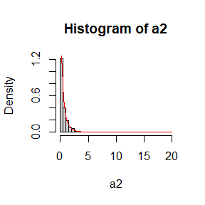

```r
n=1e3
a1=rgamma(n,4,2)
a2=rexp(n,a1)
hist(a2,breaks=seq(0,20,0.5),freq = F)
curve(64*(2+x)^(-5),add = T,col='red')
```

# 2020-10-13

## Question 1

5.1 Compute a Monte Carlo estimate of
$$\int_{0}^{\pi/3}\sin t dt$$
and compare your estimate with the exact value of the integral.

## Answer 1

$\because \int_{0}^{\pi/3}\sin t dt=\int_{0}^{\pi/3}\frac{\pi}{3}\sin t \frac{3}{\pi} dt$

let $g(t)=\frac{\pi}{3}\sin t,X\sim U(0,\frac{\pi}{3})$

$\therefore \int_{0}^{\pi/3}\sin t dt=\int_{0}^{\pi/3} \frac{3}{\pi} g(t)dt=E[g(X)]$

The Monte Carlo estimate is

```r
set.seed(3456)
n <- 1e4
x <- runif(n,0,pi/3)
g <- function(x) sin(x)*pi/3
theta.hat <- mean(g(x))       #the Monte Carlo estimate
theta <- cos(0)-cos(pi/3)    #the exact value of the integral
print(c(theta.hat,theta))
```

```
## [1] 0.5054554 0.5000000
```

## Question 2

5.7 Refer to Exercise 5.6. Use a Monte Carlo simulation to estimate $\theta$ by the antithetic variate approach and by the simple Monte Carlo method. Compute an empirical estimate of the percent reduction in variance using the antithetic variate. Compare the result with the theoretical value from Exercise 5.6.

## Answer 2

$\theta=E[e^{U}]=\int_{0}^{1}e^{u}du ,U\sim U(0,1)$

```r
set.seed(3456)
n <- 1e4
x <- runif(n,0,1)
theta_1 <- mean(exp(x))                    #theta_1: by the simple Monte Carlo estimate
m <- 5e3
y <- runif(m,0,1)
theta_2 <- mean((exp(y)+exp(1-y))/2)       #theta_2: by the antithetic variate approach
theta <- exp(1)-1                          #theta: the exact value of the integral
th <- c(theta_1,theta_2,theta)
names(th) <- c('theta_1.','theta_2.','theta.')
print(th)
```

```
## theta_1. theta_2.   theta.
## 1.727533 1.718328 1.718282
```

Let $\hat{\theta}_{c}$ be the estimator achieved by using antithetic variates approach. For $m$ replicates, $var(\hat{\theta}_{c})$ is

$$\begin{aligned}
var(\hat{\theta}_{c}) &= \frac{1}{m}var(\frac{e^{U}-e^{(1-U)}}{2}) \\
&= \frac{1}{4m}(var(e^{U})+var(e^{1-U})+2cov(e^{U},e^{1-U})) \\
&= \frac{1}{4m}(e^2+2e-1-4(e-1)^2) \\
&= \frac{0.01564999}{4m} \\
&= \frac{1}{m}0.003912497
\end{aligned}$$

Let $\hat{\theta}$ be the estimator achieved by using simple MC. For $m$ replicates, $var(\hat{\theta})$ is

$$\begin{aligned}
var(\hat{\theta}) &= \frac{1}{m}var(e^{U}) \\
&= \frac{1}{m}(\frac{e^2-1}{2}-(e-1)^2) \\
&= \frac{1}{m}0.2420351
\end{aligned}$$
The result with the theoretical value from Exercise 5.6 is $1-\frac{var(\hat{\theta}_{c})}{var(\hat{\theta})}=1-\frac{0.003912497}{0.2420351}=0.983835$ .

```r
set.seed(3456)
n <- 1e4
x <- runif(n,0,1)
var_theta_c <- var((exp(x)+exp(1-x))/2) #the sample variance of the estimate achieved by using antithetic approach
var_theta <- var(exp(x))                #the sample variance of the estimate achieved by using simple MC
pr <- c(0.983835,1-var_theta_c/var_theta)     #pr: the percent reduction and an empirical estimate of the percent reduction
names(pr)=c('the result from Exercise5.6.','empirical estimate.')
print(pr)
```

```
## the result from Exercise5.6.          empirical estimate.
##                    0.9838350                    0.9834817
```

An empirical estimate of the percent reduction in variance using the antithetic variate is $0.9834817$ .

## Question 3

5.11 If $\hat{\theta}_{1}$ and $\hat{\theta}_{2}$ are unbiased estimators of $\theta$,and $\hat{\theta}_{1}$ and $\hat{\theta}_{2}$ are antithetic,we derived that $c^{*}=1/2$ is the optimal constant that minimizes the variance of $\hat{\theta}_{c}=c\hat{\theta}_{1}+(1-c)\hat{\theta}_{2}$. Derive $c^{*}$ for the general case. That is, if $\hat{\theta}_{1}$ and $\hat{\theta}_{2}$ are any two unbiased estimators of $\theta$, find the value $c^{*}$ that minimizes the variance of the estimator $\hat{\theta}_{c}=c\hat{\theta}_{1}+(1-c)\hat{\theta}_{2}$ in question (5.11).($c^{*}$ will be a function of the variances and the covariance of the estimators.)

## Answer 3

for the general case,$\hat{\theta}_{c}=c\hat{\theta}_{1}+(1-c)\hat{\theta}_{2}$

$$\begin{aligned}
& var(\hat{\theta}_{c}) \\
=& var(c\hat{\theta}_{1}+(1-c)\hat{\theta}_{2}) \\
=& c^{2}var(\hat{\theta}_{1})+(1-c)^{2}var(\hat{\theta}_{2})+2c(1-c)cov(\hat{\theta}_{1},\hat{\theta}_{2}) \\
=& (var(\hat{\theta}_{1})+var(\hat{\theta}_{2})-2cov(\hat{\theta}_{1},\hat{\theta}_{2}))c^{2}-(2var(\hat{\theta}_{2})-2cov(\hat{\theta}_{1},\hat{\theta}_{2}))c+var(\hat{\theta}_{2}) \\
=& (var(\hat{\theta}_{1})+var(\hat{\theta}_{2})-2cov(\hat{\theta}_{1},\hat{\theta}_{2}))(c-\frac{var(\hat{\theta}_{2})-cov(\hat{\theta}_{1},\hat{\theta}_{2})}{var(\hat{\theta}_{1})+var(\hat{\theta}_{2})-2cov(\hat{\theta}_{1},\hat{\theta}_{2})})^{2}+ \\
& var(\hat{\theta}_{2})-\frac{(var(\hat{\theta}_{2})-cov(\hat{\theta}_{1},\hat{\theta}_{2}))^{2}}{var(\hat{\theta}_{1})+var(\hat{\theta}_{2})-2cov(\hat{\theta}_{1},\hat{\theta}_{2})}
\end{aligned}$$

clearly, when $c=\frac{var(\hat{\theta}_{2})-cov(\hat{\theta}_{1},\hat{\theta}_{2})}{var(\hat{\theta}_{1})+var(\hat{\theta}_{2})-2cov(\hat{\theta}_{1},\hat{\theta}_{2})}$, the variance of the estimator has a minimum.

$\therefore c^*=\frac{var(\hat{\theta}_{2})-cov(\hat{\theta}_{1},\hat{\theta}_{2})}{var(\hat{\theta}_{1})+var(\hat{\theta}_{2})-2cov(\hat{\theta}_{1},\hat{\theta}_{2})}$

# 2020-10-20

## Question 1

5.13 Find two importance functions $f_1$ and $f_2$ that are supported on $(1,\infty)$ and are ‘close’ to
$$g(x)=\frac{x^2}{\sqrt{2\pi}}e^{-x^2/2},x>1$$
Which of your two importance functions should produce the smaller variance in estimating
$$\int_{1}^{\infty}\frac{x^2}{\sqrt{2\pi}}e^{-x^2/2}dx$$
by importance sampling? Explain.

## Answer 1

The candidates for the importance functions are:

1.Normal distribution density function with parameters 1.5 and 1: $f_1(x)=\frac{1}{\sqrt{2\pi}}\exp(-\frac{(x-1.5)^2}{2})$

2.Gamma distribution density function with parameters 4 and 2:$\alpha=4,\beta=2,f_2(x)=dgamma(x,4,2)$

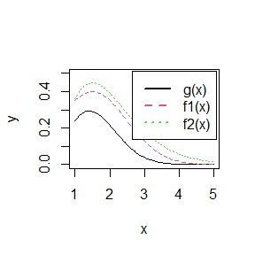

```r
m=1e4
theta_hat <- numeric(2)
se <- numeric(2)

g <- function(x) (x^2*exp(-x^2/2)/sqrt(2*pi)) * (x>=1)
f1 <- function(x) dnorm(x,1.5,1)
f2 <- function(x) dgamma(x,4,2)

par(mfrow=c(1,1))
curve(g(x),xlim = c(1,5),ylim = c(0,0.5),ylab = 'y')
curve(f1(x),xlim = c(1,5),ylim = c(0,0.5),add = T,col = 2,lty = 2)
curve(f2(x),xlim = c(1,5),ylim = c(0,0.5),add = T,col = 3,lty = 3)
legend("topright", legend = c('g(x)','f1(x)','f2(x)'),
           lty = 1:3, lwd = 2, inset = 0.02, col=1:3)
```

```r
set.seed(1234)

x <- rnorm(m,1.5,1)          #using f1
fg <- g(x) / dnorm(x,1.5,1)
theta_hat[1] <- mean(fg)
se[1] <- sd(fg)

x <- rgamma(m,4,2)          #using f2
fg <- g(x) / dgamma(x,4,2)
theta_hat[2] <- mean(fg)
se[2] <- sd(fg)

k <- rbind(theta_hat,se)
colnames(k) <- c('f1','f2')

print(k)
```

```
##                  f1        f2
## theta_hat 0.4082362 0.3991982
## se        0.3010635 0.2532093
```

because 0.3010635 > 0.2532093, therefore, $f_2(x)$ produce the smaller variance in estimating.

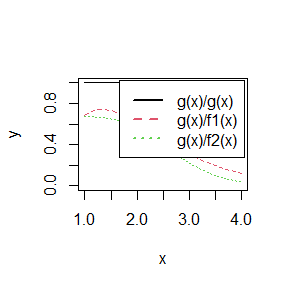

```r
par(mfrow=c(1,1))
curve(g(x)/g(x),xlim = c(1,4),ylim = c(0,1),ylab = 'y')
curve(g(x)/f1(x),xlim = c(1,4),ylim = c(0,1),add = T,col = 2,lty = 2)
curve(g(x)/f2(x),xlim = c(1,4),ylim = c(0,1),add = T,col = 3,lty = 3)
legend("topright", legend = c('g(x)/g(x)','g(x)/f1(x)','g(x)/f2(x)'),
           lty = 1:3, lwd = 2, inset = 0.02, col=1:3)
```

according to the picture,we can see that the curve of $g(x)/f_2(x)$ is flatter than the curve of $g(x)/f_1(x)$, therefore, $f_2(x)$ is closer to $g(x)$ and the variance of using $f_2(x)$ is smaller.

## Question 2

5.15 Obtain the stratified importance sampling estimate in Example 5.13 and compare it with the result of Example 5.10.

## Answer 2

The result of example 5.10:

The best result was obtained with importance function $f_3(x)=e^{-x}/(1 − e^{-1}), 0<x<1$ with the estimate $\hat{\theta}^{I} = 0.5257801$ and an estimated standard error $se^{I} = 0.0970314$.

The stratified importance sampling estimate in Example 5.13:

```r
m <- 1e4       # sample size in each sub-interval
k <- 5         # number of the sub-intervals
g <- function(x) exp(-x)/(1+x^2)
f <- function(x) exp(-x)/(1-exp(-1))   #importance function
theta.hat <- numeric(5)
sigma2.hat <- numeric(5)

set.seed(4567)
for (j in 0:4) {
  u <- runif(m)
  x <- -log(1-u*(1-exp(-1)))
  fg <- (g(x) * (x>j/k) * (x<(j+1)/k)) / (exp(-x) / (1-exp(-1)))
  theta.hat[j+1] <- mean(fg)
  sigma2.hat[j+1] <- var(fg)
}
theta <- sum(theta.hat)
se <- sqrt(sum(sigma2.hat)/m)

pa <- c(theta,se)
names(pa) <- c('theta_SI','se_SI')

print(pa)
```

```
##    theta_SI       se_SI
## 0.528442268 0.004681724
```

therefore, $\hat{\theta}^{SI} = 0.528442268$ is similar to $\hat{\theta}^{I}$,the estimated standard error $se^{SI} = 0.004681724 < se^{I}$. The stratified importance sampling estimate will provide smaller estimated standard error.

## Question 3

6.4 Suppose that $X_1,...,X_n$ are a random sample from a from a lognormal distribution with unknown parameters. Construct a 95% confidence interval for the parameter $\mu$. Use a Monte Carlo method to obtain an empirical estimate of the confidence level.

## Answer 3

$\because X_1,...,X_n$ are a random sample from a from a lognormal distribution with unknown parameters,$\therefore Y_1=\ln X_1,...,Y_n=\ln X_n \sim N(\mu,\sigma^2)$.

$EX=\exp(\mu + \frac{\sigma^2}{2})$

a 95% confidence interval for the parameter $\mu$ is :
$$\frac{\sum_{i=1}^{n}\ln X_i}{n} \pm t_{n-1}(\alpha/2)\frac{S}{\sqrt{n}}, S^2=\frac{1}{n-1}\sum_{i=1}^{n}(\ln X_i-\frac{\sum_{i=1}^{n}\ln X_i}{n})^2$$

```r
n <- 20
m <- 1000
alpha <- 0.05
mu <- 1         #set logX~N(1,4)
sigma <- 2

#general n random numbers from a lognormal distribution with unknown parameters
U <- replicate(m, expr = {
  y <- rnorm(n,1,2)
  x <- exp(y)
  c(mean(y)-sd(y)*qt(1-alpha/2,n-1)/sqrt(n),mean(y)+sd(y)*qt(1-alpha/2,n-1)/sqrt(n))
} )

print(sum(U[1,]<1 & U[2,]>1)/m)   #empirical estimate of the confidence level.
```

```
## [1] 0.96
```

## Question 4

6.5 Suppose a 95% symmetric t-interval is applied to estimate a mean, but the sample data are non-normal. Then the probability that the confidence interval covers the mean is not necessarily equal to 0.95. Use a Monte Carlo experiment to estimate the coverage probability of the t-interval for random samples of $\chi^2(2)$ data with sample size $n = 20$. Compare your t-interval results with the simulation results in Example 6.4. (The t-interval should be more robust to departures from normality than the interval for variance.)

## Answer 4

$\frac{\bar{X}-\mu}{S/\sqrt{n}} \sim t_{n-1}$

95% symmetric t-interval is: $\bar{X} \pm \frac{S\cdot t_{n-1}(\alpha/2)}{\sqrt{n}}$

```r
n <- 20
m <- 1000
alpha <- 0.05
set.seed(4553)
CL <- replicate(1000, expr = {
  x <- rchisq(n,2)       #random samples of chisp^2 data
  c(mean(x)-qt(1-alpha/2,n-1)*sd(x)/sqrt(n),mean(x)+qt(1-alpha/2,n-1)*sd(x)/sqrt(n))
} )

cp <- mean(CL[2,]>2 & CL[1,]<2)   #coverage probability
print(cp)
```

```
## [1] 0.921
```

comparing with the example 6.6, 0.921>0.773 ,the t-interval is more robust to departures from normality than the interval for variance.

# 2020-10-27

## Question 1

6.7 Estimate the power of the skewness test of normality against symmetric Beta$(\alpha,\alpha)$ distributions and comment on the results. Are the results different for heavy-tailed symmetric alternatives such as $t(\nu)$?

## Answer 1

Set confidence level is 0.05.

```r
skb <- function(x){
    #compute the sample coefficient of skewness
  xbar <- mean(x)
  b <- mean((x-xbar)^3)/(mean((x-xbar)^2))^1.5
  return(b)
}

alpha <- c(0,0.1,0.2,0.5,2,3,4,6,10,20,30,40,50,60,70,80,90,100)
al <- 0.05          #confidence level
n <- 20
m <- 1e4
N <- length(alpha)
pwr <- numeric(N)

cv <- qnorm(1-al/2, 0, sqrt(6*(n-2) / ((n+1)*(n+3))))  #critical value for the skewness test

set.seed(3444)
for (j in 1:N) {    #for each alpha
  a <- alpha[j]
  sktests <- numeric(m)
  for (i in 1:m) {   #for each replicate
    x <- rbeta(n,a,a)
    sktests[i] <- as.integer(abs(skb(x)) >= cv)
  }
  pwr[j] <- mean(sktests)
}
se <- sqrt(pwr*(1-pwr)/m)      #standard errors
p <- cbind(pwr,se)
rownames(p) <- paste(rep('alpha=',N),alpha,sep = '')
knitr::kable(p)
```

|  | pwr | se |
| --- | --- | --- |
| alpha=0 | 0.0428 | 0.0020241 |
| alpha=0.1 | 0.0384 | 0.0019216 |
| alpha=0.2 | 0.0340 | 0.0018123 |
| alpha=0.5 | 0.0141 | 0.0011790 |
| alpha=2 | 0.0103 | 0.0010096 |
| alpha=3 | 0.0129 | 0.0011284 |
| alpha=4 | 0.0166 | 0.0012777 |
| alpha=6 | 0.0221 | 0.0014701 |
| alpha=10 | 0.0355 | 0.0018504 |
| alpha=20 | 0.0443 | 0.0020576 |
| alpha=30 | 0.0459 | 0.0020927 |
| alpha=40 | 0.0465 | 0.0021057 |
| alpha=50 | 0.0488 | 0.0021545 |
| alpha=60 | 0.0499 | 0.0021774 |
| alpha=70 | 0.0497 | 0.0021732 |
| alpha=80 | 0.0517 | 0.0022142 |
| alpha=90 | 0.0510 | 0.0022000 |
| alpha=100 | 0.0510 | 0.0022000 |

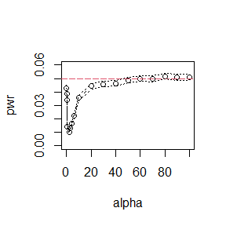

```r
    #plot power vs alpha
plot(alpha, pwr, type = "b", ylim = c(0,0.06))
abline(h = .05, lty = 5, col = 2)
lines(alpha, pwr+se, lty = 3)
lines(alpha, pwr-se, lty = 3)
```

It’s easy to see that , when $\alpha$ is large enough , the power is similarly to the confidence level.

For heavy-tailed symmetric alternatives such as $t(\nu)$.Let $\nu = 1,2,5,10,100,200,400$

```r
nu <- c(1,2,5,10,100,200,400)
alpha <- 0.05          #confidence level
n <- 30
m <- 2000
N <- length(nu)
pwr <- numeric(N)

cv <- qnorm(1-alpha/2,0,sqrt(6*(n-2)/((n+1)*(n+3))))  #critical value for the skewness test

set.seed(3444)
for (j in 1:N) {    #for each alpha
  sktests <- numeric(m)
  for (i in 1:m) {   #for each replicate
    x <- rt(n,nu[j])
    sktests[i] <- as.integer(abs(skb(x)) >= cv)
  }
  pwr[j] <- mean(sktests)
}
se <- sqrt(pwr*(1-pwr)/m)      #standard errors
p <- cbind(pwr,se)
rownames(p) <- paste(rep('nu=',N),nu,sep = '')
knitr::kable(p)
```

|  | pwr | se |
| --- | --- | --- |
| nu=1 | 0.8380 | 0.0082388 |
| nu=2 | 0.5965 | 0.0109701 |
| nu=5 | 0.2660 | 0.0098804 |
| nu=10 | 0.1590 | 0.0081768 |
| nu=100 | 0.0660 | 0.0055518 |
| nu=200 | 0.0470 | 0.0047324 |
| nu=400 | 0.0455 | 0.0046599 |

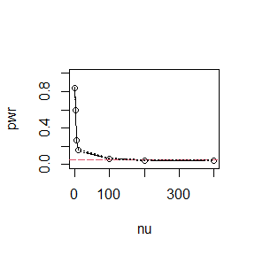

```r
    #plot power vs alpha
plot(nu, pwr, type = "b", ylim = c(0,1))
abline(h = .05, lty = 5, col = 2)
lines(nu, pwr+se, lty = 3)
lines(nu, pwr-se, lty = 3)
```

Also easy to see that , when $\nu \rightarrow \infty$, $power \rightarrow 0.05$.

## Question 2

6.8 Refer to Example 6.16. Repeat the simulation, but also compute the F test of equal variance, at significance level $\hat{\alpha} \doteq 0.055$. Compare the power of the Count Five test and F test for small, medium, and large sample sizes. (Recall that the F test is not applicable for non-normal distributions.)

## Answer 2

$\hat{\alpha} \doteq 0.055$

```r
c5t <- function(x, y) {     #count five test
  outx <- sum((x-mean(x))>max((y-mean(y))))+sum((x-mean(x))<min((y-mean(y))))
  outy <- sum((y-mean(y))>max((x-mean(x))))+sum((y-mean(y))<min((x-mean(x))))
  # return 1 (reject) or 0 (do not reject H0)
  return(as.integer(max(c(outx, outy))>5))
}
ft <- function(x, y){    #F test of equal variance
  f <- var.test(x,y)
  return(as.integer(f$p.value<0.05))
}

m <- 2000
n <- c(10,20,40,100)     #10, 20, 40 for small, medium, and large sample sizes
N <- length(n)
c5t.power <- numeric(N)
ft.power <- numeric(N)

# generate samples under H1 to estimate power
sigma1 <- 1
sigma2 <- 1.5
set.seed(2789)
for (i in 1:N) {
  k <- replicate(m, expr={
    x <- rnorm(20, 0, sigma1)
    y <- rnorm(20, 0, sigma2)
    c(ft(x, y),c5t(x,y))
  })
  ft.power[i] <- mean(k[1,])
  c5t.power[i] <- mean(k[2,])
}

p <- cbind(ft.power,c5t.power)
rownames(p) <- paste(rep('n=',3),n,sep='')
knitr::kable(p)
```

|  | ft.power | c5t.power |
| --- | --- | --- |
| n=10 | 0.4175 | 0.3205 |
| n=20 | 0.4085 | 0.3070 |
| n=40 | 0.3910 | 0.3055 |
| n=100 | 0.4025 | 0.3135 |

## Question 3

6.C Repeat Examples 6.8 and 6.10 for Mardia’s multivariate skewness test. Mardia [187] proposed tests of multivariate normality based on multivariate generalizations of skewness and kurtosis. If $X$ and $Y$ are iid, the multivariate population skewness $\beta_{1,d}$ is defined by Mardia as
$$\beta_{1,d}=E[(X-\mu)^T\Sigma^{-1}(Y-\mu)]^3$$
Under normality, $\beta_{1,d}=0$. The multivariate skewness statistic is
$$b_{1,d}=\frac{1}{n^2}\sum_{i,j=1}^{n}((X_i-\bar{X})^T\hat{\Sigma}^{-1}(X_j-\bar{X}))^3$$
where $\hat{\Sigma}$ is the maximum likelihood estimator of covariance. Large values of $b_{1,d}$ are significant. The asymptotic distribution of $nb_{1,d}/6$ is chisquared with $d(d + 1)(d + 2)/6$ degrees of freedom.

## Answer 3

it takes a long time to run the code.

like example 6.8:

```r
msk <- function(x) {    #computes the sample skewness coeff.
  hat.sigma <- cov(x)     #maximum likelihood estimator of covariance
  xbar <- apply(x,2,mean)  #Take the average of each column
  n <- nrow(x)
  b <- matrix(rep(0,n*n),ncol = n)
  for (i in 1:n) {
    for (j in 1:n) {
      b[i,j] <- (t(as.matrix(x[i,]-xbar)) %*% solve(hat.sigma) %*% as.matrix(x[j,]-xbar))^3
    }
  }
  return(mean(b))
}

n <- c(10,30,50)
#lack of the result of n=500 and n=300 which takes too much time to run the code
N <- length(n)
d <- 2   #The dimension
cv <- qchisq(0.95,d*(d+1)*(d+2)/6)       #crit. values
#we are doing length(n) different simulations
p.reject <- numeric(N) #to store sim. results
m <- 3e3     #num. repl. each sim.

library(MASS)
mu <- c(0,0)
Sigma <- matrix(c(1,0.1,0.1,1),nrow = 2)

set.seed(4563)
for (i in 1:N) {
  sktests <- replicate(m,expr = {
    x <- mvrnorm(n[i],mu,Sigma)
    as.integer(n[i]*msk(x)/6 >= cv )
  })
  p.reject[i] <- mean(sktests) #proportion rejected
}

names(p.reject) <- paste(rep('n=',N),n,sep='')
knitr::kable(round(p.reject,5))
```

|  | x |
| --- | --- |
| n=10 | 0.00000 |
| n=30 | 0.02533 |
| n=50 | 0.03667 |

when $n\rightarrow \infty$, t1e rate is close to 0.05.

like example 6.10:

The contaminated normal distribution is denoted by
$$(1-\epsilon)N(\mu=(0,0)',\Sigma_1)+\epsilon N(\mu=(0,0)',\Sigma_2),0<\epsilon<1$$
where
$$\Sigma_1=
\begin{pmatrix}
1 & 0 \\
0 & 1
\end{pmatrix}
,
\Sigma_2=
\begin{pmatrix}
100 & 0 \\
0 & 100
\end{pmatrix}$$

```r
gen <- function(d,n,mu,sigma1,sigma2){
  x <- matrix(1:(d*n),ncol=d)
  sa <- sample(c(1, 2), replace = TRUE,size = n, prob = c(1-e, e))
  for (k in 1:n) {
    if(sa[k]==1) sigma <- sigma1 else sigma <- sigma2
    x[k,] <- mvrnorm(1,c(0,0),sigma)
  }
  return(x)
}

alpha <- 0.1
n <- 30
d <- 2
m <- 100
epsilon <- c(seq(0, .15, .01), seq(.15, 1, .05))
N <- length(epsilon)
pwr <- numeric(N)
#critical value for the skewness test
cv1 <- qchisq(alpha/2,d*(d+1)*(d+2)/6)
cv2 <- qchisq(1-alpha/2,d*(d+1)*(d+2)/6)

mu <- c(0,0)
sigma1 <- matrix(c(1,0,0,1),ncol=2)
sigma2 <- matrix(c(10,0,0,10),ncol=2)
library(MASS)

for (j in 1:N) { #for each epsilon
  e <- epsilon[j]
  sktests <- numeric(m)
  sktests <- replicate(m,expr = {
    x <- gen(d,n,mu,sigma1,sigma2)
    as.integer(msk(x) >= cv2 | msk(x) <= cv1)
  })
  pwr[j] <- mean(sktests)
}
print(pwr)
```

```
##  [1] 0.69 0.65 0.48 0.44 0.39 0.34 0.34 0.34 0.29 0.19 0.31 0.15 0.25 0.18 0.18
## [16] 0.14 0.13 0.11 0.10 0.11 0.10 0.23 0.22 0.15 0.22 0.27 0.37 0.43 0.43 0.46
## [31] 0.58 0.60 0.61 0.65
```

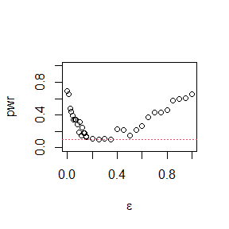

```r
plot(epsilon, pwr, type = "b",xlab = bquote(epsilon), ylim = c(0,1))
abline(h = .1, lty = 3,col = 2)
```

when $\epsilon \in (0.2,0.4))$,the power is close to 0.1, the power is highest when ε is about 0 and 1.

## Question 4

If we obtain the powers for two methods under a particular simulation setting with 10,000 experiments: say, 0.651 for one method and 0.676 for another method. Can we say the powers are different at 0.05 level?

1.What is the corresponding hypothesis test problem?

2.What test should we use? Z-test, two-sample t-test, paired-t test or McNemar test?

3.What information is needed to test your hypothesis?

## Answer 4

1.$power_1$:the power of the first method under a particular simulation;$power_2$:the power of the second method under a particular simulation.

the corresponding hypothesis test problem:

$H_{0}:\frac{power_1}{power_2}=1$ or $H_{0}:power_1-power_2=0$

2.we can use Z-test, paired-t test and McNemar test

3.3.For these test, what we already know is the number of experiments and the value of power(the probability that we reject the null hypothesis correctly). To conduct this test, we also need to know the significance of both methods for each sample.

# 2020-11-03

7.1 Compute a jackknife estimate of the bias and the standard error of the correlation statistic in Example 7.2.

## Answer 1

For jackknife method,

$\hat{bias}(\hat{\theta})=(n-1)(\bar{\theta}^*-\hat{\theta})$

$\hat{se}(\hat{\theta})=\sqrt{\frac{(n-1)}{n}\sum_i(\theta_i^*-\hat{\theta})^2}$

For two datas ‘law’ and ‘law82’,compute a jackknife estimate of the bias and the standard error of the correlation statistic:

```r
library(bootstrap)
# 15 law schools.
#jackknife estimate of bias and standard error
n1 <- nrow(law)  #sample size
corr1.hat <- cor(law[,1], law[,2])
corr1.star <- numeric(n1)
for (i in 1:n1) {
  laww <- law[-i,]
  corr1.star[i] <- cor(laww[,1], laww[,2])
}
bias.law <- (n1-1)*(mean(corr1.star)-corr1.hat)
se.law <- (n1-1)*(sum((corr1.star-mean(corr1.star))^2))/n1
e.law <- c(bias.law,se.law)
names(e.law) <- c('bias','se')

# 82 law schools
#jackknife estimate of bias and standard error
n2 <- nrow(law82)  #sample size
corr2.hat <- cor(law82[,1], law82[,2])
corr2.star <- numeric(n2)
for (i in 1:n2) {
  laww82 <- law82[-i,]
  corr2.star[i] <- cor(laww82[,1], laww82[,2])
}
bias.law82 <- (n2-1)*(mean(corr2.star)-corr2.hat)
se.law82 <- (n2-1)*(sum((corr2.star-mean(corr2.star))^2))/n2
e.law82 <- c(bias.law82,se.law82)
names(e.law82) <- c('bias','se')

es <- rbind(e.law,e.law82)
knitr::kable(es)
```

|  | bias | se |
| --- | --- | --- |
| e.law | -0.0064736 | 0.0203116 |
| e.law82 | -0.0019114 | 0.0112309 |

## Question 2

7.5 Refer to Exercise 7.4. Compute 95% bootstrap confidence intervals for the mean time between failures $1/\lambda$ by the standard normal, basic, percentile, and BCa methods. Compare the intervals and explain why they may differ.

## Answer 2

In exercise 7.4 , the times between failures $T \sim Exp(\lambda)$

suppose there are n observed samples $T_1,...,T_n iid\sim Exp(\lambda)$,

$\ln L(\lambda) = \sum_{i=1}^{n}\log(\lambda e^{-\lambda T_i})=n\log \lambda-\lambda \sum_{i=1}^{n}T_i$

$\frac{\partial \ln L}{\partial \lambda}=0$,$1/\lambda =\frac{1}{n}\sum_{i=1}^{n}T_i=\bar{T}$

```r
library(boot)
air <- as.matrix(aircondit)
theta.mean <- mean(air)      #1/lambda

boot.lambda <- function(x,i) mean(x[i])
bs <- boot(data = air,statistic = boot.lambda,R = 1000)
ci <- boot.ci(bs,type=c("norm","basic","perc","bca"))

CI95 <- rbind(ci$normal[2:3],ci$basic[4:5],ci$percent[4:5],ci$bca[4:5])
colnames(CI95) <- c('L','U')
row.names(CI95) <- c('95% CI by the standard normal method:','95% CI by the basic method:','95% CI by the percentile method:','95% CI by the BCa method:')

knitr::kable(CI95)
```

|  | L | U |
| --- | --- | --- |
| 95% CI by the standard normal method: | 33.52837 | 181.8011 |
| 95% CI by the basic method: | 26.87356 | 173.0000 |
| 95% CI by the percentile method: | 43.16667 | 189.2931 |
| 95% CI by the BCa method: | 52.70366 | 209.9704 |

The range of BCa intevel is the widest, the range of Basic intevel is the narrowest.

Due to different assumptions on the sample and different methods used, the calculated interval is different.

## Question 3

7.8 Refer to Exercise 7.7. Obtain the jackknife estimates of bias and standard error of $\hat{\theta}$.

## Answer 3

$\hat{\theta}=\frac{\hat{\lambda}_1}{\sum_{i=1}^{n}\hat{\lambda}_i}$

```r
library(bootstrap) #the data scor is in the package bootstrap
n <- nrow(scor)
lambda <- eigen(cov(scor))$values
theta.hat <- lambda[1]/sum(lambda)

theta.j <- numeric(n)
for (i in 1:n) {
  sscor <- scor[-i,]
  ssigma <- cov(sscor)
  lambda.j <- eigen(ssigma)$values
  theta.j[i] <- lambda.j[1]/sum(lambda.j)
}
theta.j.bias <- (n-1)*(mean(theta.j)-theta.hat)
theta.j.se <- sqrt((n-1)*var(theta.j)/n)

jack.p <- c(theta.j.bias,theta.j.se)
names(jack.p) <- c('bias','se')

print(jack.p)
```

```
##        bias          se
## 0.001069139 0.005312565
```

## Question 4

7.11 In Example 7.18, leave-one-out (n-fold) cross validation was used to select the best fitting model. Use leave-two-out cross validation to compare the models.

## Answer 4

Linear:$Y=\beta_0+\beta_1 X+\varepsilon$

Quadratic:$Y=\beta_0+\beta_1 X+\beta_2 X^2+\varepsilon$

Exponential:$\log Y=\log \beta_0+\beta_1 X+\varepsilon$

Log-Log:$\log Y=\beta_0+\beta_1 \log X+\varepsilon$

```r
library(DAAG)
chem <- ironslag$chemical    #变量名:x: chemical
magn <- ironslag$magnetic    #变量名:y: magnetic

n <- length(magn)

# for n-fold cross validation
# fit models on leave-two-out samples
sa <- sample(rep(1:ceiling(n/2),2),n,replace = F) #将数据分成14类
e1 <- e2 <- e3 <- e4 <- numeric(ceiling(n/2))

for (i in 1:ceiling(n/2)) {
  x <- chem[sa!=i]
  y <- magn[sa!=i]
  x.test <- chem[sa==i]
  y.test <- magn[sa==i]

  J1 <- lm(y ~ x)
  yhat1 <- J1$coef[1] + J1$coef[2] * x.test
  e1[i] <- mean((y.test - yhat1)^2)

  J2 <- lm(y ~ x + I(x^2))
  yhat2 <- J2$coef[1] + J2$coef[2] * x.test +J2$coef[3] * x.test^2
  e2[i] <- mean((y.test - yhat2)^2)

  J3 <- lm(log(y) ~ x)
  logyhat3 <- J3$coef[1] + J3$coef[2] * x.test
  yhat3 <- exp(logyhat3)
  e3[i] <- mean((y.test - yhat3)^2)

  J4 <- lm(log(y) ~ log(x))
  logyhat4 <- J4$coef[1] + J4$coef[2] * log(x.test)
  yhat4 <- exp(logyhat4)
  e4[i] <- mean((y.test - yhat4)^2)

}

E <- c(mean(e1),mean(e2),mean(e3),mean(e4))
names(E) <- c('Linear','Quadratic','Exponential','Log-Log')
print(E)
```

```
##      Linear   Quadratic Exponential     Log-Log
##    19.26660    17.44692    18.14395    20.19249
```

According to the prediction error criterion, Model 2, the quadratic model, would be the best fit for the data.

The fitted regression equation for Model 2 is
$$\hat{Y} = 24.49262 − 1.39334X + 0.05452X^2.$$

# 2020-11-10

## Question 1

8.3 The Count 5 test for equal variances in Section 6.4 is based on the maximum number of extreme points. Example 6.15 shows that the Count 5 criterion is not applicable for unequal sample sizes. Implement a permutation test for equal variance based on the maximum number of extreme points that applies when sample sizes are not necessarily equal.

## Answer 1

Set $n_1=20$,$n_2=30$,$X,Y$ are from the standard normal distribution.

```r
maxn <- function(x, y) {
  #the maximum number of extreme points
  X <- x-mean(x)
  Y <- y-mean(y)
  outx <- sum(X > max(Y)) + sum(X < min(Y))
  outy <- sum(Y > max(X)) + sum(Y < min(X))
  return(max(c(outx, outy)))
}

n1 <- 20
n2 <- 30
n <- n1+n2
mu1 <- mu2 <- 0
sigma1 <- sigma2 <- 1
set.seed(3432)
x <- rnorm(n1, mu1, sigma1)
y <- rnorm(n2, mu2, sigma2)
v <- maxn(x,y)
z <- c(x,y)
R <- 9999
#permutation test
perm <- replicate(R,expr = {
  sa <- sample(1:n, size = n1, replace = FALSE)
  x1 <- z[sa]-mean(z[sa])
  y1 <- z[-sa]-mean(z[-sa])
  maxn(x1,y1)
})
p <- mean(c(v,perm) >= v)
print(p)
```

```
## [1] 0.5587
```

set $\alpha=0.05$,$\because \hat{p}=0.5587>0.05$,therefore we can’t reject $H_0$ at significance level $\alpha$. These two distributions are the same.

## Question 2

Design experiments for evaluating the performance of the NN, energy, and ball methods in various situations. (1)Unequal variances and equal expectations (2)Unequal variances and unequal expectations (3)Non-normal distributions: t distribution with 1 df (heavy-tailed distribution), bimodel distribution (mixture of two normal distributions) (4)Unbalanced samples (say, 1 case versus 10 controls) Note: The parameters should be chosen such that the powers are distinguishable (say, range from 0.3 to 0.8).

## Answer 2

```r
library(RANN)    # For NN method
library(energy)  # For energy method
library(Ball)    # For Ball method
library(boot)

Tn <- function(z,ix,sizes,k) {
  n1 <- sizes[1]
  n2 <- sizes[2]
  n <- n1 + n2
  if(is.vector(z)) z <- data.frame(z,0)
  z <- z[ix,];
  NN <- nn2(data=z, k=k+1) # what's the first column?
  block1 <- NN$nn.idx[1:n1,-1]
  block2 <- NN$nn.idx[(n1+1):n,-1]
  i1 <- sum(block1 < n1 + .5)
  i2 <- sum(block2 > n1+.5)
  (i1 + i2) / (k * n)
}

eqdist.nn <- function(z,sizes,k){
  boot.obj <- boot(data=z,statistic=Tn,R=R,sim = "permutation", sizes = sizes,k=k)
  ts <- c(boot.obj$t0,boot.obj$t)
  p.value <- mean(ts>=ts[1])
  list(statistic=ts[1],p.value=p.value)
}
```

(1)Unequal variances and equal expectations

```r
n1 <- n2 <- 50
N <- c(n1,n2)
m <- 1e3
R <- 999
d <- 2
k <- 3
mu1 <- mu2 <- 0
sigma1 <- 1
sigma2 <- 0.7
p.values <- matrix(NA,m,3)

for(i in 1:m){
  x <- matrix(rnorm(n1*d,mu1,sigma1),ncol=d)
  y <- matrix(rnorm(n2*d,mu2,sigma2),ncol=d)
  z <- rbind(x,y)
  p.values[i,1] <- eqdist.nn(z,N,k)$p.value
  p.values[i,2] <- eqdist.etest(z,sizes=N,R=R)$p.value
  p.values[i,3] <- bd.test(x=x,y=y,R=999,seed=i*1818)$p.value
}

alpha <- 0.1
pow1 <- colMeans(p.values<alpha)
names(pow1) <- c('p.NN','p.energy','p.Ball')
print(pow1)
```

```
##     p.NN p.energy   p.Ball
##    0.385    0.464    0.828
```

(2)Unequal variances and unequal expectations

```r
n1 <- n2 <- 50
N <- c(n1,n2)
m <- 1e3
R <- 999
d <- 2
k <- 3
mu1 <- 0
mu2 <- 0.35
sigma1 <- 1
sigma2 <- 0.8
p.values <- matrix(NA,m,3)

for(i in 1:m){
  x <- matrix(rnorm(n1*d,mu1,sigma1),ncol=d)
  y <- matrix(rnorm(n2*d,mu2,sigma2),ncol=d)
  z <- rbind(x,y)
  p.values[i,1] <- eqdist.nn(z,N,k)$p.value
  p.values[i,2] <- eqdist.etest(z,sizes=N,R=999)$p.value
  p.values[i,3] <- bd.test(x=x,y=y,R=999,seed=i*2626)$p.value
}

alpha <- 0.1
pow2 <- colMeans(p.values<alpha)
names(pow2) <- c('p.NN','p.energy','p.Ball')
print(pow2)
```

```
##     p.NN p.energy   p.Ball
##    0.438    0.843    0.834
```

(3)Non-normal distributions

```r
n1 <- n2 <- 50
N <- c(n1,n2)
m <- 1e3
R <- 999
d <- 2
k <- 3
mu1 <- 0
mu2 <- 0
sigma1 <- 2
sigma2 <- 1.2
p.values <- matrix(NA,m,3)
 #x:t distribution with 1 df
 #y:t bimodel distribution
for(i in 1:m){
  x <- matrix(rt(n1*d,df=1),ncol=d);
  y <- matrix(sample(c(rnorm(n2,mu1,sigma1),rnorm(n2,mu2,sigma2))),ncol=d)
  z <- rbind(x,y)
  p.values[i,1] <- eqdist.nn(z,N,k)$p.value
  p.values[i,2] <- eqdist.etest(z,sizes=N,R=R)$p.value
  p.values[i,3] <- bd.test(x=x,y=y,R=999,seed=i*4535)$p.value
}

alpha <- 0.05
pow3 <- colMeans(p.values<alpha)
names(pow3) <- c('p.NN','p.energy','p.Ball')
print(pow3)
```

```
##     p.NN p.energy   p.Ball
##    0.320    0.733    0.614
```

(4)Unbalanced samples

```r
n1 <- 10
n2 <- 20
N <- c(n1,n2)
m <- 1e3
R <- 999
d <- 2
k <- 3
mu1 <- mu2 <- 0
sigma1 <- sigma2 <- 1
p.values <- matrix(NA,m,3)

for(i in 1:m){
  x <- matrix(rnorm(n1*d,mu1,sigma1),ncol=d)
  y <- matrix(rnorm(n2*d,mu2,sigma2),ncol=d)
  z <- rbind(x,y)
  p.values[i,1] <- eqdist.nn(z,N,k)$p.value
  p.values[i,2] <- eqdist.etest(z,sizes=N,R=R)$p.value
  p.values[i,3] <- bd.test(x=x,y=y,R=999,seed=i*1234)$p.value
}

alpha <- 0.3
pow4 <- colMeans(p.values<alpha)
names(pow4) <- c('p.NN','p.energy','p.Ball')
print(pow4)
```

```
##     p.NN p.energy   p.Ball
##    0.253    0.313    0.287
```

# 2020-11-17

## Question 1

9.4 Implement a random walk Metropolis sampler for generating the standard Laplace distribution (see Exercise 3.2). For the increment, simulate from a normal distribution. Compare the chains generated when different variances are used for the proposal distribution. Also, compute the acceptance rates of each chain.

## Answer 1

The standard Laplace distribution has density $f(x)=\frac{1}{2}e^{-|x|},x\in R$. Variance of the standard Laplace distribution is 2.

$r(x_t,y)=\frac{f(Y)}{f(X_t)}=\frac{\frac{1}{2}e^{-|Y|}}{\frac{1}{2}e^{-|X_t|}}=e^{|X_t|-|Y|}$

Metropolis sampler:

```r
# a function to generate the chain, given the
# parameters n and σ, initial value X0, and the length of the chain, N.
rwM.gen.chain <- function(sigma,x0,N) {
  x <- numeric(N)
  x[1] <- x0
  u <- runif(N)
  k <- 0
  for (i in 2:N) {
    y <- rnorm(1, x[i-1], sigma)
    r <- exp(abs(x[i-1])-abs(y))
    if (u[i] <= r){
      x[i] <- y
      k <- k + 1
      } else
        x[i] <- x[i-1]
    }
  return(list(x=x,accept=k/N ))
  # accept:the acceptance rates of chain
}

N <- 2000
sigma <- c(0.05,0.5,2,16)

x0 <- 5   # start = 5
ch1 <- rwM.gen.chain(sigma[1], x0, N)
ch2 <- rwM.gen.chain(sigma[2], x0, N)
ch3 <- rwM.gen.chain(sigma[3], x0, N)
ch4 <- rwM.gen.chain(sigma[4], x0, N)

accep <- c(ch1$accept, ch2$accept, ch3$accept, ch4$accept)
names(accep) <- c('sigma=0.05','sigma=0.5','sigma=2','sigma=16')
print(accep)
```

```
## sigma=0.05  sigma=0.5    sigma=2   sigma=16
##     0.9815     0.8335     0.5255     0.0915
```

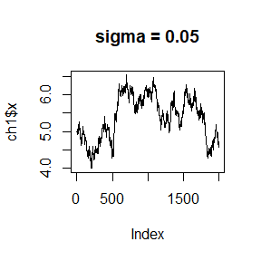

```r
plot(ch1$x,type ='l',main ='sigma = 0.05')
```

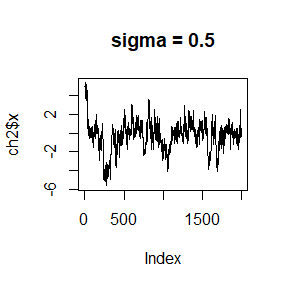

```r
plot(ch2$x,type ='l',main ='sigma = 0.5')
```

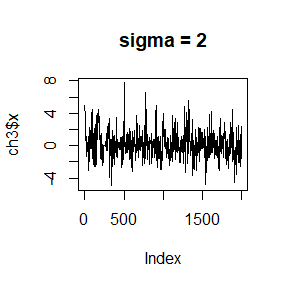

```r
plot(ch3$x,type ='l',main ='sigma = 2')
```

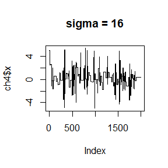

```r
plot(ch4$x,type ='l',main ='sigma = 16')
```

As the variance of the proposal distribution increases, the acceptance rate of the chain decreases.

Chain 1 has not converged to the target in 2000 iterations. Chain 2 is converging very slower than Chain 3 and requires a longer burn-in period. Chain 3 is mixing well and converging to the target distribution after a short burn-in period. Chain 4 converges, but it is inefficient,the ratios $r(X_t, Y)$ are smaller and most of the candidate points are rejected.

## Question 2

For Exercise 9.4, use the Gelman-Rubin method to monitor convergence of the chain, and run the chain until it converges approximately to the target distribution according to $\hat{R} < 1.2$.

## Answer 2

```r
Gelman.Rubin <- function(psi) {
  # psi[i,j] is the statistic psi(X[i,1:j]) for chain in i-th row of X
  # generate r.hat
  psi <- as.matrix(psi)
  n <- ncol(psi)
  k <- nrow(psi)
  psi.i <- rowMeans(psi)            #row means
  B <- n*var(psi.i)                 #between variance est.
  psi.w <- apply(psi, 1, "var")     #within variances
  W <- mean(psi.w)                  #within est.
  hat.v.psi <- W*(n-1)/n + (B/n)    #upper variance est.
  r.hat <- hat.v.psi/W              #G-R statistic
  return(r.hat)
}

#use the function 'rwM.gen.chain' in answer 1 to generate the chain

sigma <- 2          #parameter of proposal distribution
k <- 4              #number of chains to generate
n <- 15000          #length of chains
b <- 1000           #burn-in length

#choose overdispersed initial values
x0 <- c(-10,-5,5,10)

#generate the chains
X <- matrix(0,nrow=k,ncol=n)
for (i in 1:k) X[i,] <- rwM.gen.chain(sigma,x0[i],n)$x

#compute diagnostic statistics
psi <- t(apply(X, 1, cumsum))

for (i in 1:nrow(psi)) psi[i,] <- psi[i,]/(1:ncol(psi))
r <- Gelman.Rubin(psi)
cat('r.hat=',r)
```

```
## r.hat= 1.099286
```

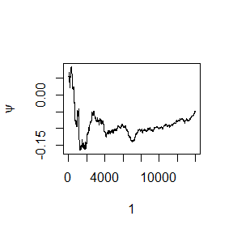

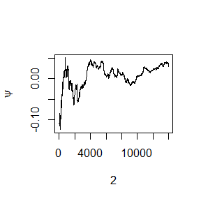

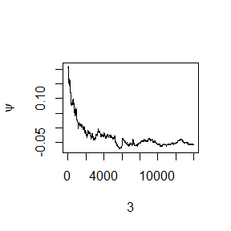

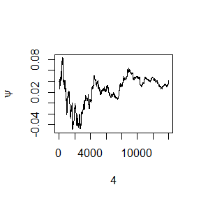

```r
#plot psi for the four chains

for (i in 1:k) plot(psi[i, (b+1):n], type="l",xlab=i, ylab=bquote(psi))
```

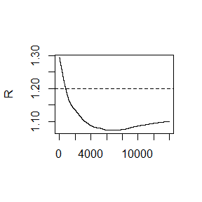

```r
    #restore default

#plot the sequence of R-hat statistics
rhat <- rep(0, n)
for (j in (b+1):n) rhat[j] <- Gelman.Rubin(psi[,1:j])

plot(rhat[(b+1):n], type="l", xlab="", ylab="R")
abline(h=1.2, lty=2)
```

set different $\sigma$ of the proposal distribution.$\sigma=0.05,0.5,2,4$.

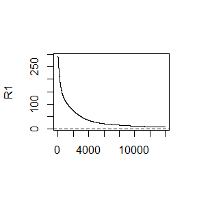

```r
sigma <- c(0.05,0.5,2,4)
k <- 4              #number of chains to generate
n <- 15000          #length of chains
b <- 1000

x0 <- c(-10,-5,5,10)
X1 <- X2 <- X3 <- X4 <- matrix(0,nrow=k,ncol=n)
for (i in 1:k){
  X1[i,] <- rwM.gen.chain(sigma[1],x0[i],n)$x
  X2[i,] <- rwM.gen.chain(sigma[2],x0[i],n)$x
  X3[i,] <- rwM.gen.chain(sigma[3],x0[i],n)$x
  X4[i,] <- rwM.gen.chain(sigma[4],x0[i],n)$x
}
psi1 <- t(apply(X1,1,cumsum))
psi2 <- t(apply(X2,1,cumsum))
psi3 <- t(apply(X3,1,cumsum))
psi4 <- t(apply(X4,1,cumsum))

for (i in 1:nrow(psi1)){
  psi1[i,] <- psi1[i,]/(1:ncol(psi1))
  psi2[i,] <- psi2[i,]/(1:ncol(psi2))
  psi3[i,] <- psi3[i,]/(1:ncol(psi3))
  psi4[i,] <- psi4[i,]/(1:ncol(psi4))
}

rhat1 <- rhat2 <- rhat3 <- rhat4 <-rep(0, n)
for (j in (b+1):n){
  rhat1[j] <- Gelman.Rubin(psi1[,1:j])
  rhat2[j] <- Gelman.Rubin(psi2[,1:j])
  rhat3[j] <- Gelman.Rubin(psi3[,1:j])
  rhat4[j] <- Gelman.Rubin(psi4[,1:j])
}

plot(rhat1[(b+1):n], type="l", xlab="", ylab="R1")
abline(h=1.2, lty=2)
```

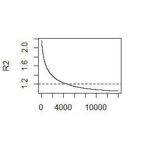

```r
plot(rhat2[(b+1):n], type="l", xlab="", ylab="R2")
abline(h=1.2, lty=2)
```

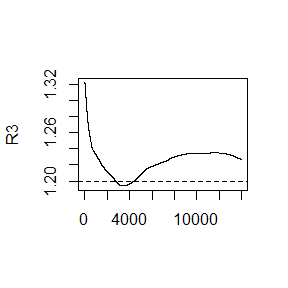

```r
plot(rhat3[(b+1):n], type="l", xlab="", ylab="R3")
abline(h=1.2, lty=2)
```

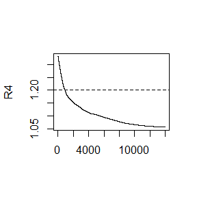

```r
plot(rhat4[(b+1):n], type="l", xlab="", ylab="R4")
abline(h=1.2, lty=2)
```

## Question 3

11.4 Find the intersection points $A(k)$ in $(0,\sqrt{k})$ of the curves
$$S_{k-1}(a)=P\left(t(k-1)>\sqrt{\frac{a^2(k-1)}{k-a^2}} \right)$$
and
$$S_{k}(a)=P\left(t(k)>\sqrt{\frac{a^2k}{k+1-a^2}} \right)$$
for k = 4:25, 100, 500, 1000, where t(k) is a Student t random variable with k degrees of freedom. (These intersection points determine the critical values for a t-test for scale-mixture errors proposed by Szekely [260].)

## Answer 3

For$S_{k}(a)=P\left(t(k)>\sqrt{\frac{a^2k}{k+1-a^2}} \right)$,$\because k>0,\therefore k+1-a^2>0,i.e.-\sqrt{k+1}<a<\sqrt{k+1}$.

$\because S_{k-1}(a)$ doesn’t make sense at $a=\sqrt{k}$,and $S_{k-1}(0)=S_{k}(0)$,$\therefore$ we set the interval to $(0.00001,\sqrt{k}-0.00001)$ in the code.

```r
 #the function of s_k(a)
sk <- function(a,k) 1-pt(sqrt(a^2*k/(k+1-a^2)),k)
 #the equation to solve the intersection points
equa <- function(a,k) sk(a,k)-sk(a,k-1)
 #the interval that the intersection points in is (0,sqrt(k))

k = c(4:25,100,500,1000)

n <- length(k)
Ak <- numeric(n)
for (i in 1:n) {
  Ak[i] <- uniroot(function(y) {equa(y,k[i])},lower = 0.00001,upper = sqrt(k[i])-0.00001)$root
}
names(Ak) <- paste(rep('k=',n),k,sep='')

knitr::kable(Ak)
```

|  | x |
| --- | --- |
| k=4 | 1.492103 |
| k=5 | 1.533548 |
| k=6 | 1.562768 |
| k=7 | 1.584421 |
| k=8 | 1.601182 |
| k=9 | 1.614523 |
| k=10 | 1.625387 |
| k=11 | 1.634409 |
| k=12 | 1.642025 |
| k=13 | 1.648540 |
| k=14 | 1.654177 |
| k=15 | 1.659098 |
| k=16 | 1.663451 |
| k=17 | 1.667288 |
| k=18 | 1.670736 |
| k=19 | 1.673841 |
| k=20 | 1.676589 |
| k=21 | 1.679139 |
| k=22 | 1.681461 |
| k=23 | 4.795821 |
| k=24 | 4.898969 |
| k=25 | 4.999990 |
| k=100 | 9.999990 |
| k=500 | 22.360670 |
| k=1000 | 31.622767 |

# 2020-11-24

## Question 1

A-B-O blood type problem:

$\cdot$ Let the three alleles be A, B, and O.

| Genotype | AA | BB | OO | AO | BO | AB | Sum |
| --- | --- | --- | --- | --- | --- | --- | --- |
| Frequency | p^2 | q^2 | r^2 | 2pr | 2qr | 2pq | 1 |
| Count | nAA | nBB | nOO | nAO | nBO | nAB | n |

$\cdot$ Observed data: $n_{A·} = n_{AA} + n_{AO} = 444$ (A-type),$n_{B·} = n_{BB} + n_{BO} = 132$ (B-type), $n_{OO} = 361$ (O-type),$n_{AB} = 63$ (AB-type).

$\cdot$ Use EM algorithm to solve MLE of p and q (consider missing data $n_{AA}$ and $n_{BB}$).

$\cdot$ Record the values of p and q that maximize the conditional likelihood in each EM steps, calculate the corresponding log-maximum likelihood values (for observed data), are they increasing?

## Answer 1

$p+q+r=1,r=1-p-q$

Observed data: $n_{A·} = n_{AA} + n_{AO} = 444$ (A-type),$n_{B·} = n_{BB} + n_{BO} = 132$ (B-type), $n_{OO} = 361$ (O-type),$n_{AB} = 63$ (AB-type)

$$n_{AA}|n_{A\cdot}\sim B(n_{A\cdot},\frac{p^2}{p^2+2pr})=B(444,\frac{p}{p+2r}), n_{BB}|n_{B\cdot}\sim B(n_{B\cdot},\frac{q^2}{q^2+2qr})=B(132,\frac{q}{q+2r})$$
Observed data likelihood:
$$\begin{aligned}
L(p,q|n_{A·},n_{B·},n_{OO},n_{AB})&=(p^2+2pr)^{n_{A·}}(q^2+2qr)^{n_{B·}}(r^2)^{n_{OO}}(2pq)^{n_{AB}} \\
&=(p^2+2pr)^{444}(q^2+2qr)^{132}(r^2)^{361}(2pq)^{63} \\
\end{aligned}$$
get $\hat{p}_0,\hat{q}_0$.

Complete data likelihood:
$$\begin{aligned}
L(p,q|n_{AA},n_{AO},n_{BB},n_{BO},n_{OO},n_{AB})&=(p^2)^{n_{AA}}(2pr)^{n_{AO}}(q^2)^{n_{BB}}(2qr)^{n_{BO}}(r^2)^{n_{OO}}(2pq)^{n_{AB}} \\
l(p,q|n_{A·},n_{B·},n_{AA},n_{BB},n_{OO},n_{AB})&=\ln L(p,q|n_{A·},n_{B·},n_{AA},n_{BB},n_{OO},n_{AB}) \\
&=\ln \{(p^2)^{n_{AA}}(2pr)^{n_{A·}-n_{AA}}(q^2)^{n_{BB}}(2qr)^{n_{B·}-n_{BB}}(r^2)^{n_{OO}}(2pq)^{n_{AB}}\} \\
&=\ln \{(p^2)^{n_{AA}}(2pr)^{n_{A·}-n_{AA}}(q^2)^{n_{BB}}(2qr)^{n_{B·}-n_{BB}}(r^2)^{n_{OO}}(2pq)^{n_{AB}}\} \\
&=\ln \{(\frac{p^2}{2pr})^{n_{AA}}(2pr)^{n_{A·}}(\frac{q^2}{2qr})^{n_{BB}}(2qr)^{n_{B·}}(r^2)^{n_{OO}}(2pq)^{n_{AB}}\} \\
&=n_{AA}\ln(\frac{p}{2r})+n_{A·}\ln (2pr)+n_{BB}\ln(\frac{q}{2r})+n_{B·}\ln (2qr)+ \\
& n_{OO}\ln r^2+n_{AB}\ln (2pq) \\
\end{aligned}$$
E-step:
$$\begin{aligned}
& E_{\hat{p},\hat{q}}[l(p,q|n_{A·},n_{B·},n_{AA},n_{BB},n_{OO},n_{AB})|n_{A·},n_{B·},n_{OO},n_{AB}] \\
=& \frac{\hat{p}n_{A·}}{\hat{p}+2\hat{r}}\ln(\frac{p}{2r})+n_{A·}\ln (2pr)+\frac{\hat{q}n_{B·}}{\hat{q}+2\hat{r}}\ln(\frac{q}{2r})+n_{B·}\ln (2qr)+n_{OO}\ln r^2+n_{AB}\ln (2pq)
\end{aligned}$$

```r
obl <- function(x){
  # Observed data likelihood
  p <- x[1]
  q <- x[2]
  r <- 1-p-q
  f <- 444*log(p^2+2*p*r) + 132*log(q^2+2*q*r) + 2*361*log(r) + 63*(log(2)+log(p)+log(q))
  return(-f)
}

e_step <- function(x,phat,qhat,rhat){
  p <- x[1]
  q <- x[2]
  r <- 1-p-q
  f <- phat*444*(log(p)-log(2*r))/(phat+2*rhat) + 444*(log(2)+log(p)+log(r)) +
    qhat*132*(log(q)-log(2*r))/(qhat+2*rhat) + 132*(log(2)+log(q)+log(r)) +
    2*361*log(r) +63*(log(2)+log(p)+log(q))
  return(-f)
}
theta0 <- optim(c(0.35,0.2),fn=obl)$par
theta <- list()   # a list to store phat and qhat
theta[[1]] <- theta1 <- theta0
k <- 1
judge <- T
while (judge == T) {
  theta0 <- theta1
  p.hat <- theta0[1]
  q.hat <- theta0[2]
  r.hat <- 1-p.hat-q.hat
  com.likeli <- function(x) e_step(x,p.hat,q.hat,r.hat) #E-step
  theta1 <- optim(theta0,fn=com.likeli)$par #M-step
   # judge whether to stop the iteration:if judge=T,go on
  judge <- abs(theta0[1]-theta1[1])>1e-8 | abs(theta0[2]-theta1[2])>1e-8
  k <- k+1
  theta[[k]] <- theta1
}
prtheta <- matrix(unlist(theta),byrow=T,ncol=2)
colnames(prtheta) <- c('phat','qhat')
print(prtheta)
```

```
##           phat      qhat
## [1,] 0.2975828 0.1027041
## [2,] 0.2976605 0.1027219
## [3,] 0.2976240 0.1027210
## [4,] 0.2976240 0.1027210
```

```r
corllv <- -sapply(theta, obl)
cat('the corresponding log-maximum likelihood values are not increasing:','\n',corllv)
```

```
## the corresponding log-maximum likelihood values are not increasing:
##  -1169.822 -1169.822 -1169.822 -1169.822
```

The corresponding log-maximum likelihood values are not increasing.

## Question 2

Exercises 3 (page 204, Advanced R).

3.Use both for loops and lapply() to fit linear models to the mtcars using the formulas stored in this list:

formulas <- list( mpg ~ disp, mpg ~ I(1 / disp), mpg ~ disp + wt, mpg ~ I(1 / disp) + wt )

## Answer 2

```r
attach(mtcars)
formulas <- list(
  mpg ~ disp,
  mpg ~ I(1 / disp),
  mpg ~ disp + wt,
  mpg ~ I(1 / disp) + wt
)
 #使用for循环
n <- length(formulas)
fit1 <- list()
for (i in 1:n) {
  fit1[[i]] <- lm(formula = formulas[[i]])
}
 #使用lapply()
fit2 <- lapply(formulas,lm)
detach(mtcars)

print(fit1)
```

```
## [[1]]
##
## Call:
## lm(formula = formulas[[i]])
##
## Coefficients:
## (Intercept)         disp
##    29.59985     -0.04122
##
##
## [[2]]
##
## Call:
## lm(formula = formulas[[i]])
##
## Coefficients:
## (Intercept)    I(1/disp)
##       10.75      1557.67
##
##
## [[3]]
##
## Call:
## lm(formula = formulas[[i]])
##
## Coefficients:
## (Intercept)         disp           wt
##    34.96055     -0.01772     -3.35083
##
##
## [[4]]
##
## Call:
## lm(formula = formulas[[i]])
##
## Coefficients:
## (Intercept)    I(1/disp)           wt
##      19.024     1142.560       -1.798
```

```r
print(fit2)
```

```
## [[1]]
##
## Call:
## FUN(formula = X[[i]])
##
## Coefficients:
## (Intercept)         disp
##    29.59985     -0.04122
##
##
## [[2]]
##
## Call:
## FUN(formula = X[[i]])
##
## Coefficients:
## (Intercept)    I(1/disp)
##       10.75      1557.67
##
##
## [[3]]
##
## Call:
## FUN(formula = X[[i]])
##
## Coefficients:
## (Intercept)         disp           wt
##    34.96055     -0.01772     -3.35083
##
##
## [[4]]
##
## Call:
## FUN(formula = X[[i]])
##
## Coefficients:
## (Intercept)    I(1/disp)           wt
##      19.024     1142.560       -1.798
```

## Question 3

Excecises 3 and 6 (page 213-214, Advanced R). Note: the anonymous function is defined in Section 10.2 (page 181, Advanced R)

3. The following code simulates the performance of a t-test for non-normal data. Use sapply() and an anonymous function to extract the p-value from every trial.

trials <- replicate(100,t.test(rpois(10, 10), rpois(7, 10)),simplify = FALSE)

Extra challenge: get rid of the anonymous function by using [[ directly.

## Answer 3

```r
trials <- replicate(100,t.test(rpois(10, 10), rpois(7, 10)),simplify = FALSE)

 # Use sapply() and an anonymous function
p_value1 <- sapply(trials,function(x) x$p.value)
print(p_value1)
```

```
##   [1] 0.31150803 0.70510408 0.66541061 0.30816493 0.98369607 0.17245675
##   [7] 0.63918834 0.01146574 0.74676349 0.83941982 0.34846713 0.95245087
##  [13] 0.42555089 0.84937756 0.73801765 0.52535757 0.48148170 0.90020486
##  [19] 0.48687995 0.92429034 0.19271531 0.74917244 0.93166570 0.93166228
##  [25] 0.92517174 0.93367545 0.79525774 0.96389757 0.18954212 0.87075482
##  [31] 0.34635255 0.85491883 0.13634576 0.54899714 0.18652278 0.65166304
##  [37] 0.75690799 0.15547016 0.22139698 0.50251270 0.48108960 0.36092102
##  [43] 0.55735404 0.22624071 0.33880853 0.59379697 0.49544179 0.84301502
##  [49] 0.60560028 0.84070263 0.60082707 0.78811486 0.27087977 0.81057521
##  [55] 0.41610595 0.04130181 0.88625754 0.28170764 0.53143410 0.30937236
##  [61] 0.53756983 0.85398966 0.98267309 0.46457502 0.62220831 0.89680508
##  [67] 0.48271344 0.73917697 0.13502411 0.98723621 0.16516892 0.02890845
##  [73] 0.20328768 0.73873431 0.50288986 0.68056226 0.44219502 0.57397368
##  [79] 0.13471981 0.60561456 0.44652384 0.90065822 0.82492317 0.88127543
##  [85] 0.82781307 0.31919508 0.16500373 0.26864248 0.71789218 0.90679087
##  [91] 0.82893009 0.36790259 0.57806382 0.55610160 0.37787645 0.66263253
##  [97] 0.14480833 0.20935937 0.23071605 0.87507939
```

```r
 # using [[ directly
p_value2 <- numeric()
for (i in 1:length(trials)) {
  p_value2[i] <- trials[[i]]$p.value
}
print(p_value2)
```

```
##   [1] 0.31150803 0.70510408 0.66541061 0.30816493 0.98369607 0.17245675
##   [7] 0.63918834 0.01146574 0.74676349 0.83941982 0.34846713 0.95245087
##  [13] 0.42555089 0.84937756 0.73801765 0.52535757 0.48148170 0.90020486
##  [19] 0.48687995 0.92429034 0.19271531 0.74917244 0.93166570 0.93166228
##  [25] 0.92517174 0.93367545 0.79525774 0.96389757 0.18954212 0.87075482
##  [31] 0.34635255 0.85491883 0.13634576 0.54899714 0.18652278 0.65166304
##  [37] 0.75690799 0.15547016 0.22139698 0.50251270 0.48108960 0.36092102
##  [43] 0.55735404 0.22624071 0.33880853 0.59379697 0.49544179 0.84301502
##  [49] 0.60560028 0.84070263 0.60082707 0.78811486 0.27087977 0.81057521
##  [55] 0.41610595 0.04130181 0.88625754 0.28170764 0.53143410 0.30937236
##  [61] 0.53756983 0.85398966 0.98267309 0.46457502 0.62220831 0.89680508
##  [67] 0.48271344 0.73917697 0.13502411 0.98723621 0.16516892 0.02890845
##  [73] 0.20328768 0.73873431 0.50288986 0.68056226 0.44219502 0.57397368
##  [79] 0.13471981 0.60561456 0.44652384 0.90065822 0.82492317 0.88127543
##  [85] 0.82781307 0.31919508 0.16500373 0.26864248 0.71789218 0.90679087
##  [91] 0.82893009 0.36790259 0.57806382 0.55610160 0.37787645 0.66263253
##  [97] 0.14480833 0.20935937 0.23071605 0.87507939
```

## Question 4

6. Implement a combination of Map() and vapply() to create an lapply() variant that iterates in parallel over all of its inputs and stores its outputs in a vector (or a matrix). What arguments should the function take?

## Answer 4

stores its outputs in a vector: FUN.VALUE=numeric(1)

stores its outputs in a matrix: FUN.VALUE=numeric(n), n=length(result)>1

stores its outputs in an array: FUN.VALUE=matrix(…), the size of the matrix is equal to the result of the function.

```r
 # lapply() variant
valapply <- function(X,FUN,FUN.VALUE,USE.NAMES = TRUE){
  FUN <- match.fun(FUN)
  answer <- Map(FUN,X)
  vapply(answer, function(x) x, FUN.VALUE = FUN.VALUE)
}

#example:
a <- list(c(1,2),c(2,3),c(1,4),c(5,5))
 # in a vector
valapply(a,mean,numeric(1))
```

```
## [1] 1.5 2.5 2.5 5.0
```

```r
 # in a matrix
valapply(a,function(x) x^2,numeric(2))
```

```
##      [,1] [,2] [,3] [,4]
## [1,]    1    4    1   25
## [2,]    4    9   16   25
```

```r
 # in an array
valapply(a,function(x) x %*% t(x),matrix(0,2,2))
```

```
## , , 1
##
##      [,1] [,2]
## [1,]    1    2
## [2,]    2    4
##
## , , 2
##
##      [,1] [,2]
## [1,]    4    6
## [2,]    6    9
##
## , , 3
##
##      [,1] [,2]
## [1,]    1    4
## [2,]    4   16
##
## , , 4
##
##      [,1] [,2]
## [1,]   25   25
## [2,]   25   25
```

# 2020-12-01

## Question

Write an Rcpp function for Exercise 9.4 (page 277, Statistical Computing with R).

Exercise9.4 Implement a random walk Metropolis sampler for generating the standard Laplace distribution (see Exercise 3.2). For the increment, simulate from a normal distribution. Compare the chains generated when different variances are used for the proposal distribution. Also, compute the acceptance rates of each chain.

Compare the corresponding generated random numbers with those by the R function you wrote before using the function “qqplot”.

Campare the computation time of the two functions with the function “microbenchmark”.

Comments your results.

## Answer

The source R code for *rw.MetropolisC* is as follows:

```r
List rw_MetropolisC(double sigma,double x0,int N){
  NumericVector x(N);
  x[0]=x0;
  NumericVector u(N);
  u=runif(N);
  double y;
  int k = 0;
  for (int i=1;i<N;i++) {
    y = rnorm(1,x[i-1],sigma);
    if (u[i] <= exp(abs(x[i-1])-abs(y))){
      x[i] = y;
      k = k+1;
    }
    else {
      x[i] = x[i-1];
    }
  }
  List out(2);
  out[0] = x;
  out[1] = k;
  return out;
}
```

using Rcpp function:

```r
library(Rcpp)
cppFunction('List rw_MetropolisC(double sigma,double x0,int N){
  NumericVector x(N);
  x[0]=x0;
  NumericVector u(N);
  u=runif(N);
  double y;
  int k = 0;
  for (int i=1;i<N;i++) {
    y = rnorm(1,x[i-1],sigma)[0];
    if (u[i] <= exp(abs(x[i-1])-abs(y))){
      x[i] = y;
      k = k+1;
    }
    else {
      x[i] = x[i-1];
    }
  }
  List out(2);
  out[0] = x;
  out[1] = k;
  return out;
  }'
)


N = 2000
sigma = c(0.05, 0.5, 2, 16)
x0 = 20
ch1.C = rw_MetropolisC(sigma[1],x0,N)
ch2.C = rw_MetropolisC(sigma[2],x0,N)
ch3.C = rw_MetropolisC(sigma[3],x0,N)
ch4.C = rw_MetropolisC(sigma[4],x0,N)

accep.C = cbind(ch1.C[[2]], ch2.C[[2]], ch3.C[[2]], ch4.C[[2]])/N
rownames(accep.C) = 'Accept rates'
colnames(accep.C) = paste('sigma=',sigma)
knitr::kable(accep.C)
```

|  | sigma= 0.05 | sigma= 0.5 | sigma= 2 | sigma= 16 |
| --- | --- | --- | --- | --- |
| Accept rates | 0.974 | 0.831 | 0.5265 | 0.1015 |

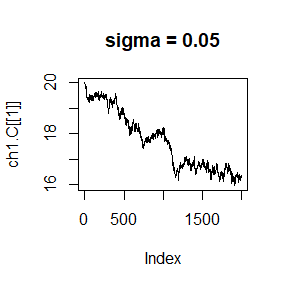

```r
plot(ch1.C[[1]],type ='l', main = 'sigma = 0.05')
```

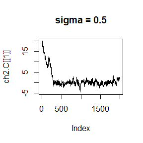

```r
plot(ch2.C[[1]],type ='l', main = 'sigma = 0.5')
```

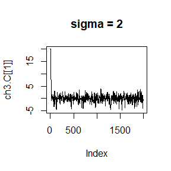

```r
plot(ch3.C[[1]],type ='l', main = 'sigma = 2')
```

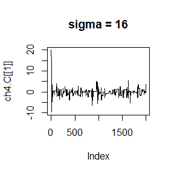

```r
plot(ch4.C[[1]],type ='l', main = 'sigma = 16')
```

The source R code for *rwM.gen.chain* is as follows:

```r
rwM.gen.chain <- function(sigma,x0,N) {
  x <- numeric(N)
  x[1] <- x0
  u <- runif(N)
  k <- 0
  for (i in 2:N) {
    y <- rnorm(1, x[i-1], sigma)
    r <- exp(abs(x[i-1])-abs(y))
    if (u[i] <= r){
      x[i] <- y
      k <- k + 1
    } else
      x[i] <- x[i-1]
  }
  return(list(x=x,accept=k/N ))
  # accept:the acceptance rates of chain
}
```

using R function:

```r
ch1 <- rwM.gen.chain(sigma[1], x0, N)
ch2 <- rwM.gen.chain(sigma[2], x0, N)
ch3 <- rwM.gen.chain(sigma[3], x0, N)
ch4 <- rwM.gen.chain(sigma[4], x0, N)

accep <- c(ch1$accept, ch2$accept, ch3$accept, ch4$accept)
names(accep) <- c('sigma=0.05','sigma=0.5','sigma=2','sigma=16')
print(accep)
```

```
## sigma=0.05  sigma=0.5    sigma=2   sigma=16
##     0.9795     0.8180     0.5300     0.1020
```

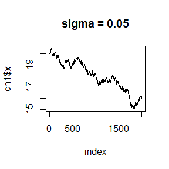

```r
index <- 1:N

plot(index,ch1$x,type ='l', main = 'sigma = 0.05')
```

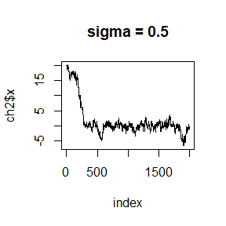

```r
plot(index,ch2$x,type ='l', main = 'sigma = 0.5')
```

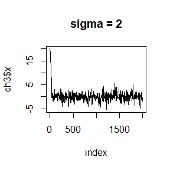

```r
plot(index,ch3$x,type ='l', main = 'sigma = 2')
```

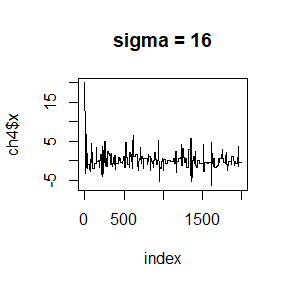

```r
plot(index,ch4$x,type ='l', main = 'sigma = 16')
```

Compare the corresponding generated random numbers with those by the R function you wrote before :

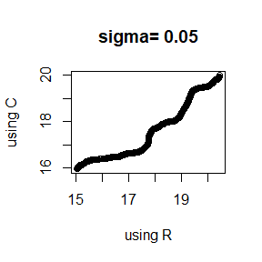

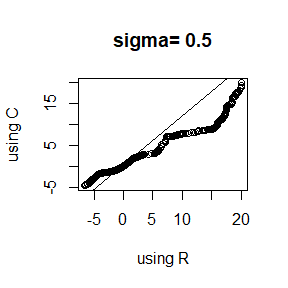

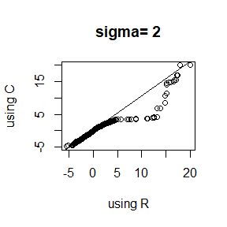

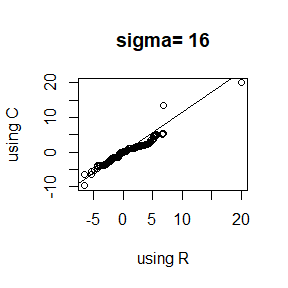

```r
x <- rbind(ch1$x,ch2$x,ch3$x,ch4$x)
y <- rbind(ch1.C[[1]],ch2.C[[1]],ch3.C[[1]],ch4.C[[1]])

for (i in 1:4) {
  qqplot(x[i,],y[i,],xlab = 'using R',
         ylab = 'using C',main=paste('sigma=',sigma[i]))
  qqline(y[i,])
}
```

```r
library(microbenchmark)
microbenchmark(ch1=rwM.gen.chain(sigma[1], x0, N),
               ch1.C=rw_MetropolisC(sigma[1],x0,N))
```

```
## Unit: microseconds
##   expr      min        lq     mean    median       uq       max neval
##    ch1 5736.001 6191.3510 7814.799 6959.3015 8605.901 16834.000   100
##  ch1.C  379.002  400.0015  454.614  423.0505  472.652   775.601   100
```

```r
microbenchmark(ch2=rwM.gen.chain(sigma[2], x0, N),
               ch2.C=rw_MetropolisC(sigma[2],x0,N))
```

```
## Unit: microseconds
##   expr      min        lq     mean   median        uq       max neval
##    ch2 5765.801 6374.4005 7916.426 6934.451 8855.7020 16184.101   100
##  ch2.C  379.101  406.8015  468.905  438.301  493.5015   854.702   100
```

```r
microbenchmark(ch3=rwM.gen.chain(sigma[3], x0, N),
               ch3.C=rw_MetropolisC(sigma[3],x0,N))
```

```
## Unit: microseconds
##   expr      min       lq     mean   median       uq       max neval
##    ch3 5645.901 6216.251 7294.538 6679.001 7497.801 11849.901   100
##  ch3.C  361.800  377.551  440.435  416.101  464.801   802.002   100
```

```r
microbenchmark(ch4=rwM.gen.chain(sigma[4], x0, N),
               ch4.C=rw_MetropolisC(sigma[4],x0,N))
```

```
## Unit: microseconds
##   expr      min        lq     mean   median        uq       max neval
##    ch4 5520.701 6039.4010 7226.233 6414.150 7053.8010 13397.801   100
##  ch4.C  334.801  347.4515  389.332  361.651  407.2505   642.401   100
```

Obviously, functions in C code take less time to run.

Using Rcpp functions to generate random numbers is faster.